Guppy colour learning project site [GitHub](https://github.com/wyatt-toure/guppy-colour-learning-project) Analysis 2 Analysis 1 Methods Home

# Analysis for ‘Colour biases in learned foraging preferences in Trinidadian guppies’

Experiment 2 Data Preparation and Analysis

M. Wyatt Toure

McGill University, Department of Biology, 1205 Docteur Penfield, Montreal, Quebec H3A 1B1, Canada

Last Update: Jul 15 2021

## Overview

This page reports the analyses for the second experiment described in ‘Colour biases in learned foraging preferences in Trinidadian guppies.’ The code run to produce the results is included on the page along with explanations of what the code is doing and why. The raw R script to reproduce the data preparation, analysis, figures, and this page are in analysis-experiment-2.Rmd. Note the code blocks that produce the figures and tables are not shown on this page as they are rather long, however the code to produce the figures and tables can also be seen in analysis-experiment-2.Rmd. To get straight to the results go to the Models section. To see how to reproduce these results please visit the How to Reproduce the Results section of the README.

## Data preparation

In this section we detail the steps taken to process the raw data produced by processing video footage with automated tracking from Noldus EthoVision (Noldus et al., 2001). The raw data can be found in the [`data/experiment-2-raw-data/`](https://github.com/wyatt-toure/guppy-colour-learning-project/tree/main/data/experiment-2-raw-data) directory. They are composed of `.xlsx` files exported from EthoVision XT Version 11. Each trial is in a separate `.xlsx` file. The full processed data are available as a `.csv` file in the file [`colour-learning-experiment-2-full-data.csv`](https://github.com/wyatt-toure/guppy-colour-learning-project/blob/main/data/colour-learning-experiment-2-full-data.csv). Descriptions of the variables found in the data set are given in the variable descriptions section of the [README](https://github.com/wyatt-toure/guppy-colour-learning-project#metadata) file.

### Downloading data

To prepare the data first we download the raw data files from the Google Drive folder they are stored in. We make use of the tidyverse package `googledrive` to do this. We put `googledrive` into a de-authorized state so we can access public Google Drive resources without a Google sign-in. We then get the list of files that are present in the Google drive directory and use a `for()` loop which downloads each file using the `drive_download()` function. The data are downloaded to the [`data/experiment-2-raw-data/`](https://github.com/wyatt-toure/guppy-colour-learning-project/tree/main/data/experiment-2-raw-data) directory.

```r
# Downloading data from Google drive

## Put googledrive into a de-authorized state
drive_deauth()

## Store link to data folder
data_folder_link <- "https://drive.google.com/drive/folders/1A8NRlBMQ-BfkgNHzEpmw6hEbgePJncLj?usp=sharing"

## Get id for data folder
data_folder_id <- drive_get(as_id(data_folder_link))

## Store the list of file names and ids found in the data folder
data_files <- drive_ls(data_folder_id)

## Loop through and download each file
for (file_x in 1:length(data_files$name)) {
      drive_download(
        as_id(data_files$id[file_x]),
        path = str_c("data/experiment-2-raw-data/",data_files$name[file_x]),
        overwrite = TRUE)
}
```

### Formatting data

Next we read in and format the raw `.xlsx` files from EthoVision which are in `data/experiment-2-raw-data/` using one of my custom functions, `read_and_format_ethovision_data()`. The code for this can be seen in [`read-and-format-ethovision-data.R`](https://github.com/wyatt-toure/guppy-colour-learning-project/blob/main/R/read-and-format-ethovision-data.R).

```r
# Reading in Data
full_data <- read_and_format_ethovision_data("data/experiment-2-raw-data/")
```

Next we add the rewarding object colour treatments to the correct guppy IDs that were established *a priori* in [`datasheet-experiment-2.Rmd`](https://github.com/wyatt-toure/guppy-colour-learning-project/blob/main/datasheet-experiment-2.Rmd). The treatments are represented by the variable `rewarding.object.colour`.

```r
## Assigning treatments
full_data <- full_data %>%
  mutate(
    rewarding.object.colour =
      case_when(
        id == "1a" ~ "blue",
        id == "1b" ~ "green",
        id == "2a" ~ "blue",
        id == "2b" ~ "blue",
        id == "3a" ~ "blue",
        id == "3b" ~ "green",
        id == "4a" ~ "green",
        id == "4b" ~ "green",
        id == "5a" ~ "green",
        id == "5b" ~ "blue",
        id == "6a" ~ "green",
        id == "6b" ~ "green",
        id == "7a" ~ "blue",
        id == "7b" ~ "blue",
        id == "8a" ~ "green",
        id == "8b" ~ "blue"
      )
  )
```

All the variables for the data set are read in as characters due to the `read_excel()` call in `read_and_format_ethovision_data()`, so we need to convert them to their appropriate data structures for the analysis. Variables are converted to either factors or numerics where appropriate using the `lapply()` function which applies a function over a vector. We apply the `as.factor()` function to categorical variables identified in the `Factors` vector and the `as.numeric()` function to the numerical variables identified in the `Numerics` vector.

For the latency measures, dashes in the raw data sheet indicate that an individual never visited the zone of interest. In being converted to numerics these values are changed to NAs. We convert these values to the maximum value which is the trial duration (300 seconds) using the `tidyr` function `replace_na()`.

```r
# Converting variables

## Factors
Factors <- c("ate", "id", "object.side", "rewarding.object.colour", "object.pair")
full_data[Factors] <- lapply(full_data[Factors], as.factor)

## Numeric
Numerics <- c(
  "trial", "left.object.visits", "time.with.left.object",
  "left.object.latency", "right.object.visits", "time.with.right.object",
  "right.object.latency", "periphery.visits", "time.in.periphery",
  "latency.to.periphery", "center.visits", "time.in.center",
  "latency.to.center", "distance.moved", "mean.velocity"
)
full_data[Numerics] <- lapply(full_data[Numerics], as.numeric)

## Latency NA replacement
full_data <- full_data %>%
  replace_na(
    list(
      left.object.latency = 300,
      right.object.latency = 300,
      latency.to.periphery = 300,
      latency.to.center = 300
    )
  )
```

### Variable creation

New variables and measures need to be created from the variables present in the raw data sheets. We do this using the `mutate()` and `case_when()` functions from the tidyverse package `dplyr`. First we invert the object side because the camera image is reversed from the perspective of the experimenter. We then create the variables `time.with.trained.object` and `time.with.untrained.object` by identifying whether the left or right object is the reward object.

The preference metrics `green.object.preference` and `rewarding.object.preference` are created by subtracting the time spent near the blue object from the time spent near the green object and subtracting the time spent near the untrained object from the time spent near the trained object respectively.

`time.with.both.objects` is obtained by summing the time spent near the left and the right object. `total.time` is obtained by summing the `time.in.periphery` with the `time.in.center`. `total.time` should be close to 300 since trials last 5 minutes (300 seconds).

We also create the variable `trial.type` to identify whether a trial is a test trial (unreinforced) or training trial (reinforced).

```r
# Creating new variables

## Inverting object side
full_data <- full_data %>%
  mutate(
    reward.object.side =
      as.factor(
        case_when(
          object.side == "left" ~ "right",
          object.side == "right" ~ "left"
        )
      )
  )

## Time with trained object
full_data <- full_data %>%
  mutate(
    time.with.trained.object =
      case_when(
        reward.object.side == "left" ~ time.with.left.object,
        reward.object.side == "right" ~ time.with.right.object
      )
  )

## Time with untrained object
full_data <- full_data %>%
  mutate(
    time.with.untrained.object =
      case_when(
        reward.object.side == "left" ~ time.with.right.object,
        reward.object.side == "right" ~ time.with.left.object
      )
  )

## Green object preference
full_data <- full_data %>%
  mutate(
    green.object.preference =
      case_when(
        rewarding.object.colour == "green" ~
        time.with.trained.object - time.with.untrained.object,

        rewarding.object.colour == "blue" ~
        time.with.untrained.object - time.with.trained.object
      )
  )

## Rewarding object preference
full_data <- full_data %>%
  mutate(
    rewarding.object.preference =
      time.with.trained.object - time.with.untrained.object
  )

## Proportionanl Rewarding object preference
full_data <- full_data %>%
  mutate(
    prop.rewarding.object.preference =
      time.with.trained.object / (time.with.trained.object + time.with.untrained.object)
  )

## Time with both objects
full_data <- full_data %>%
  mutate(
    time.with.both.objects =
      time.with.left.object + time.with.right.object
  )

## Total time
full_data <- full_data %>%
  mutate(
    total.time =
      time.in.center + time.in.periphery
  )

## Trial type
full_data <- full_data %>%
  mutate(
    trial.type =
      as.factor(
        case_when(
          trial == 0 | trial == 21 | trial == 23 |
            trial == 25 | trial == 27 | trial == 29 ~ "test",
          trial > 0 & trial < 21 ~ "training",
          trial == 22 | trial == 24 |  trial == 26 | trial == 28 ~ "refresher"
        )
      )
  )

## Assigning weights
full_data <- full_data %>%
  mutate(
    weight =
      case_when(
        id == "1a" ~ 0.29,
        id == "1b" ~ 0.10,
        id == "2a" ~ 0.20,
        id == "2b" ~ 0.11,
        id == "3a" ~ 0.20,
        id == "3b" ~ 0.12,
        id == "4a" ~ 0.21,
        id == "4b" ~ 0.11,
        id == "5a" ~ 0.18,
        id == "5b" ~ 0.13,
        id == "6a" ~ 0.15,
        id == "6b" ~ 0.11,
        id == "7a" ~ 0.31,
        id == "7b" ~ 0.13,
        id == "8a" ~ 0.17,
        id == "8b" ~ 0.14
      )
  )
```

```r
# Restrict data to only the baseline data
baseline_data <- full_data %>%
  filter(trial == 0)

# Restrict data to training data
training_data <- full_data %>%
  filter(trial.type == "training")

# Restrict data to only the baseline and re-test data
test_data <- full_data %>%
  filter(trial.type == "test")

# Change trial to factor for test trials
test_data$trial <- as.factor(test_data$trial)

# Change trial to integer for training trials
training_data$trial <- as.integer(training_data$trial)
```

### Exporting processed data

Finally we export the full data set as a `.csv` file to future proof the full data sheet in a plain text, machine-readable format. `row.names` is set to `FALSE` so that the index column is not exported into the `.csv` file.

```r
write.csv(full_data,
          file = "data/colour-learning-experiment-2-full-data.csv",
          row.names = FALSE)
```

## Models

We analysed the data from our experiment using linear mixed effect and generalized linear mixed effect models with the `lmer()` and `glmer()` functions from the `lme4` package. P-values and effective degrees of freedom were obtained using the `lmerTest` package which uses Satterthwaite’s degrees of freedom method (Kuznetsova et al., 2017). Model residuals were checked they met distributional assumptions with the `DHARMa` package. The ‘See Model Residuals’ button below the model formulas can be clicked to see the residual diagnostic plots produced by `DHARMa` for that particular model.

### Model 1 - Preference for the green object at baseline

This first model contains the data for all individual guppies during the initial test. We looked at the green object preference of all guppies in an intercept only model to see if the green object preference at baseline was significantly different from zero. `green.object.preference` is the time spent near the green object subtracted by the time spent near the blue object.

```r
baseline_data_model <-
  lm(green.object.preference ~ 1,
    data = baseline_data
  )
```

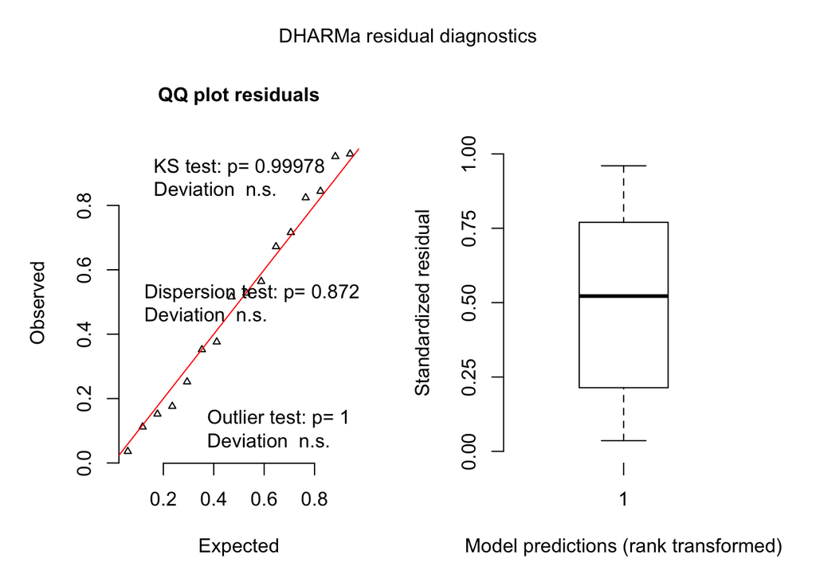

```r
simulationOutput <- simulateResiduals(fittedModel = baseline_data_model)
plot(simulationOutput)
```

```r
# Saving plot to figs directory
ggsave(
  filename = "exp-2-model-1-residual-plot.png",
  plot = (plot(simulationOutput)),
  path = "figs/exp-2/exp-2-residual-plots",
  device = "png",
  dpi = 300
)
```

##### Result

| Factor | Estimate | Std. Error | T statistic | P value |
| --- | --- | --- | --- | --- |
| Intercept | 0.138 | 3.786 | 0.036 | 0.971 |

Just as in experiment 1, there is no significant preference for the green object over the blue object across all guppies during the initial test (p = 0.971).

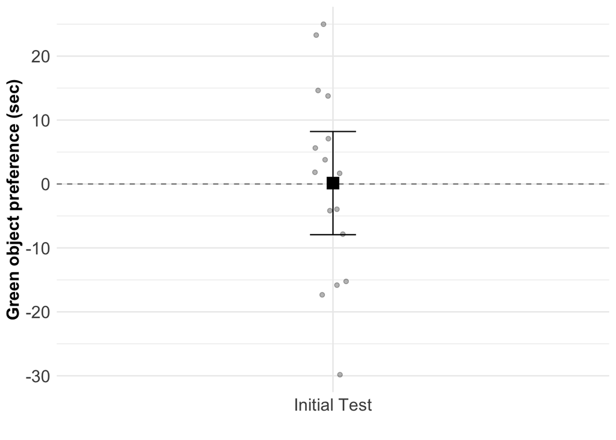

Figure 1: Preference for the green object relative to the blue object across all guppies at baseline. Negative values represent more time spent with the blue object, positive values indicate more time spent with the green object. Data are means ± 95% CI

### Model 2 - Preference for the rewarding object during training

During all of training fish spent on average 68.7% of the trial time near an object during training. 56.3% of trial time was spent near the rewarding object and 12.4% of trial time was spent near the unrewarding object.

To see how fish behaved during training our second model asks whether the preference for the rewarding object changes throughout training and whether the change in rewarding object preference is different between the treatments.

- **Response variable:** `rewarding.object.preference` is the time (seconds) spent near the rewarding object subtracted by the time spent near the unrewarding object
- **Fixed effect:** `rewarding.object.colour` is the identity of the rewarding object (blue or green)
- **Fixed effect:** `trial` is the number of the training trial. In this model it is supplied as an integer
- **Random effect:** `id` is the identity of the individual fish

```r
training_data_model <-
  lmer(rewarding.object.preference ~ trial * rewarding.object.colour + (1 | id),
    data = training_data
  )
```

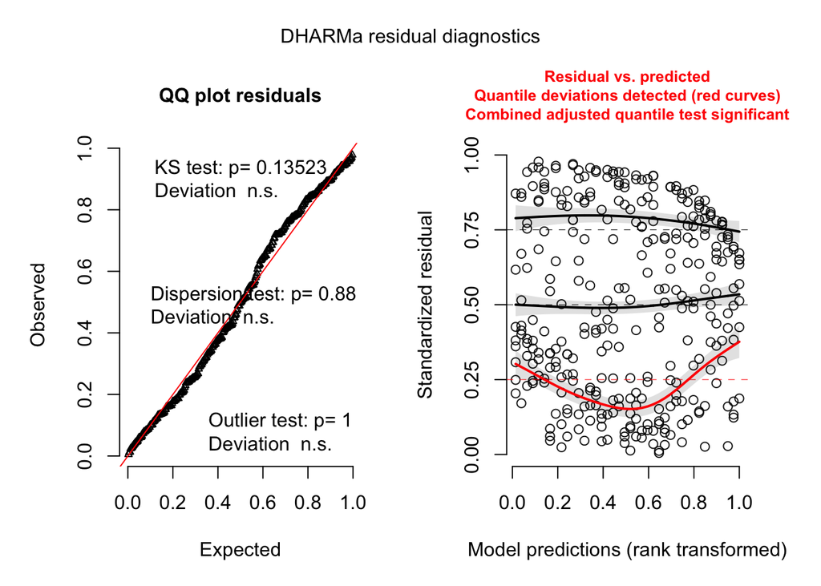

```r
# Residual diagnostics
simulationOutput <- simulateResiduals(
  fittedModel = training_data_model,
  n = 1000
)
plot(simulationOutput)
```

```r
# Saving plot to figs directory
ggsave(
  filename = "model-2-residual-plot.png",
  plot = (plot(simulationOutput)),
  path = "figs/exp-2/exp-2-residual-plots",
  device = "png",
  dpi = 300
)
```

There is a slight deviation in the lower quantile but no indication in the residual plot of a gross model misfit.

##### Results

[output not shown]

There was a significant interaction effect between trial and rewarding object colour (p = 0.003) indicating that the change in rewarding object preference has a different trend depending on the rewarding object colour. We used the `emtrends()` function from `emmeans` to estimate and compare the trends.

```r
training_data_model_trends <-
  emtrends(training_data_model,
    pairwise ~ rewarding.object.colour,
    var = "trial"
  )
```

| Rewarding object colour | Trial trend | Std. Error | df | Lower CL | Upper CL |
| --- | --- | --- | --- | --- | --- |
| blue | 5.497 | 1.348 | 302 | 2.845 | 8.149 |
| green | 11.298 | 1.348 | 302 | 8.646 | 13.951 |

Guppies that were trained to green objects increased their relative preference for rewarding objects by 11.3 seconds on average each trial whereas guppies trained to blue objects increased their relative preference for rewarding objects by 5.5 seconds on average each trial. Thus, while both groups increased their preference for their respective rewarding objects over training, green trained guppies increased their preference at a rate that was 2.1x faster than blue trained guppies (Figure 2).

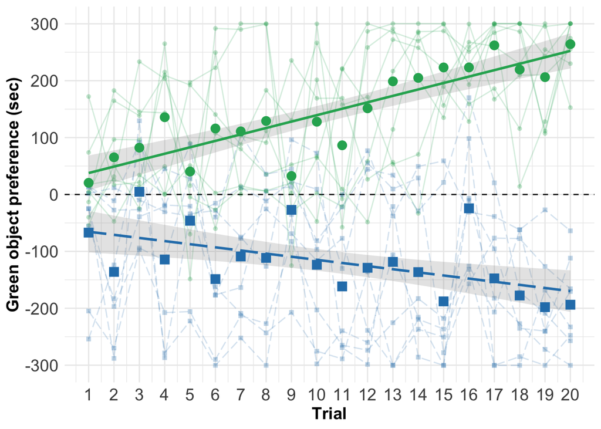

Figure 2: Relative preference for the green object in both treatments during training trials (trials 1-20). Negative values represent more time spent with the blue object, positive values indicate more time spent with the green object. Light lines connect individuals across trials. Subjects were consistently rewarded for approaching the blue object (dashed lines) or the green object (solid lines).

### Model 3 - Preference for the rewarded object during testing

To determine whether learning had occurred we used the initial preference for the rewarding object colour as a control and compared each probe test trial to this control trial for each treatment. To do so we fit a generalized linear mixed effects model with a Gaussian distribution with fixed effects of trial and rewarding object colour (green versus blue), a random effect of individual identity, and a response variable of rewarding object preference. To control for heterogeneous variance across trials we additionally modelled the variance due to trial. We then compared the estimated marginal means of each test trial rewarding object preference to the initial rewarding object preference to establish whether learning had occurred. Learning was assumed to have occurred if the change in preference between the initial trial (serving as the control) and the test trial was significant.

```r
test_data_model_glm <-
  glmmTMB(rewarding.object.preference ~
            trial * rewarding.object.colour + (1 |id) +
            diag(0 + trial |id),
  data = test_data,
  family = gaussian
  )
```

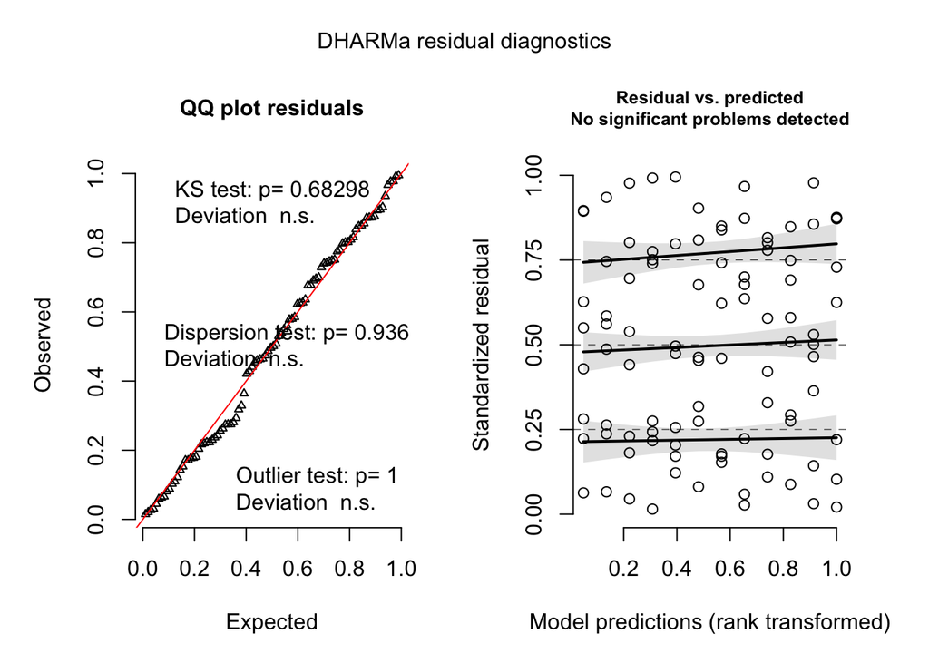

```r
simulationOutput <- simulateResiduals(fittedModel = test_data_model_glm, n = 1000)
plot(simulationOutput)
```

```r
# Saving plot to figs directory
ggsave(
  filename = "exp-2-model-3-residual-plot.png",
  plot = (plot(simulationOutput)),
  path = "figs/exp-2/exp-2-residual-plots/",
  device = "png",
  dpi = 300
)
```

##### Results

```r
test_data_model_emmeans <- emmeans(test_data_model_glm,
        specs = trt.vs.ctrl ~ rewarding.object.colour:trial,
        by = "rewarding.object.colour")
```

| contrast | rewarding.object.colour | estimate | SE | df | t.ratio | p.value |
| --- | --- | --- | --- | --- | --- | --- |
| Probe 1 - Initial | blue | 33 | 15.359 | 76 | 2.179 | 0.127 |
| Generalization 1 - Initial | blue | 25 | 16.185 | 76 | 1.543 | 0.4 |
| Generalization 2 - Initial | blue | -1 | 20.828 | 76 | -0.046 | 1 |
| Probe 2 - Initial | blue | 9 | 19.376 | 76 | 0.445 | 0.965 |
| Odour - Initial | blue | 19 | 11.552 | 76 | 1.683 | 0.323 |
| Probe 1 - Initial | green | 48 | 15.359 | 76 | 3.093 | 0.013 |
| Generalization 1 - Initial | green | 14 | 16.185 | 76 | 0.838 | 0.825 |
| Generalization 2 - Initial | green | 74 | 20.828 | 76 | 3.532 | 0.003 |
| Probe 2 - Initial | green | 50 | 19.376 | 76 | 2.596 | 0.048 |
| Odour - Initial | green | 82 | 11.552 | 76 | 7.082 | < .001 |

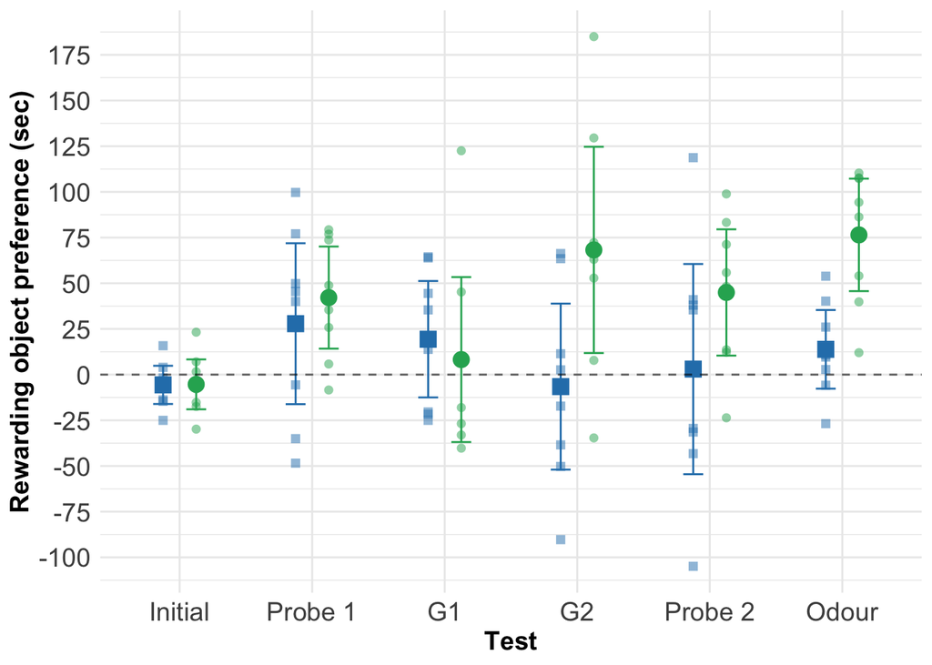

Figure 3: Rewarding object preferences for an initial test prior to training and 5 probe tests after training. During training, fish were rewarded for approaching the blue object (blue squares) or the green object (green circles). At test, no food reward was present. Dashed line represents an equal preference for either object. Large blue sqaures and large green circles are means ± 95% CI, smaller blue sqaures and green circles are individual data points

### Model 4 - Is there a difference in feeding attempts between treatments?

A discrepancy in reinforcement between treatments may influence performance on a final preference test. To see whether there was a difference in feeding between treatments we counted the number of trials in which an individual fish ate throughout all of training and compared the feeding counts between treatments. To do this we fit a generalized linear model with a negative binomial distribution. The response variable ‘feeding count’ is a sum of the number of trials in which a guppy ate.

- **Response variable:** `feeding.count` is the number of trials in which an individual fish ate
- **Fixed effect:** `rewarding.object.colour` is the identity of the rewarding object (blue or green)

```r
feeding_data_model <-
  glm.nb(feeding.count ~ rewarding.object.colour,
    data = feeding_data
  )
```

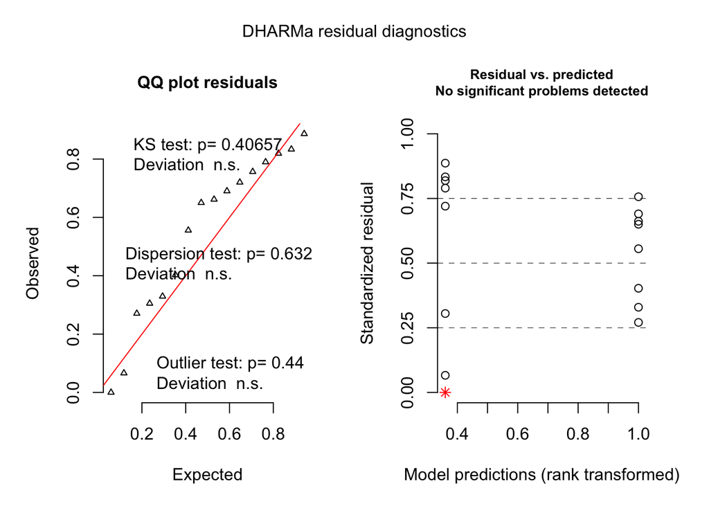

```r
simulationOutput <- simulateResiduals(fittedModel = feeding_data_model)
plot(simulationOutput)
```

```r
# Saving plot to figs directory
ggsave(
  filename = "exp-2-model-4-residual-plot.png",
  plot = (plot(simulationOutput)),
  path = "figs/exp-2/exp-2-residual-plots/",
  device = "png",
  dpi = 300
)
```

##### Results

| Factor | Estimate | Std. Error | T statistic | P value |
| --- | --- | --- | --- | --- |
| Intercept | 2.612 | 0.176 | 14.834 | 0.000 |
| Rewarding object colour | 0.045 | 0.248 | 0.181 | 0.857 |

We found no significant difference in the number of trials individuals fed between green-rewarded and blue-rewarded fish (Figure 4, p = 0.857).

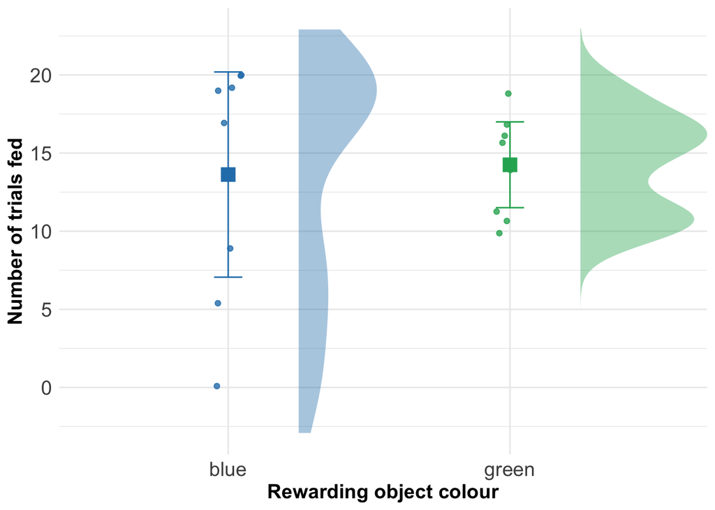

Figure 4: Average number of trials in which a fish fed during training. Data are means ± 95% confidence intervals with probability density functions of the data to the right of the raw data.

## Miscellaneous descriptive statistics

After trial 21 the guppies were all weighed. The weights ranged from 0.1 to 0.31 grams. Guppies weighed on average 0.17 grams. Blue-trained guppies weighed more than green-trained guppies (0.19 grams vs 0.14 grams) but this difference was not statistically significant.

| Factor | Estimate | Std. Error | T statistic | P value |
| --- | --- | --- | --- | --- |
| (Intercept) | 0.189 | 0.022 | 8.770 | 0.000 |
| rewarding.object.colourgreen | -0.045 | 0.030 | -1.479 | 0.161 |

## Packages used

The analyses on this page were done with R version 3.6.2 (2019-12-12) and with functions from packages listed in Table 1. This page was written in Rmarkdown and rendered with `knitr`. To see the full list of dependencies for all packages used as well as their versions please visit the How to Reproduce the Results section of the README.

Table 1: All packages used for this analysis. The dependencies for these packages as well as their versions can be found in the README file.

| Package | Version | Reference |
| --- | --- | --- |
| broom | 0.5.5 | David Robinson and Alex Hayes (2020). broom: Convert Statistical Analysis Objects into Tidy Tibbles. R package version 0.5.5. https://CRAN.R-project.org/package=broom |
| broom.mixed | 0.2.6 | Ben Bolker and David Robinson (2020). broom.mixed: Tidying Methods for Mixed Models. R package version 0.2.6. https://CRAN.R-project.org/package=broom.mixed |
| carData | 3.0.3 | John Fox, Sanford Weisberg and Brad Price (2019). carData: Companion to Applied Regression Data Sets. R package version 3.0-3. https://CRAN.R-project.org/package=carData |
| cowplot | 1.0.0 | Claus O. Wilke (2019). cowplot: Streamlined Plot Theme and Plot Annotations for ‘ggplot2.’ R package version 1.0.0. https://CRAN.R-project.org/package=cowplot |
| DHARMa | 0.3.3.0 | Florian Hartig (2020). DHARMa: Residual Diagnostics for Hierarchical (Multi-Level / Mixed) Regression Models. R package version 0.3.3.0. http://florianhartig.github.io/DHARMa/ |
| dplyr | 1.0.3 | Hadley Wickham, Romain François, Lionel Henry and Kirill Müller (2021). dplyr: A Grammar of Data Manipulation. R package version 1.0.3. https://CRAN.R-project.org/package=dplyr |
| effects | 4.1.4 | John Fox and Sanford Weisberg (2019). An R Companion to Applied Regression, 3rd Edition. Thousand Oaks, CA http://tinyurl.com/carbook |
| emmeans | 1.5.1 | Russell Lenth (2020). emmeans: Estimated Marginal Means, aka Least-Squares Means. R package version 1.5.1. https://CRAN.R-project.org/package=emmeans |
| ggplot2 | 3.3.3 | H. Wickham. ggplot2: Elegant Graphics for Data Analysis. Springer-Verlag New York, 2016. |
| ggpubr | 0.2.5 | Alboukadel Kassambara (2020). ggpubr: ‘ggplot2’ Based Publication Ready Plots. R package version 0.2.5. https://CRAN.R-project.org/package=ggpubr |
| glmmTMB | 1.0.0 | Mollie E. Brooks, Kasper Kristensen, Koen J. van Benthem, Arni Magnusson, Casper W. Berg, Anders Nielsen, Hans J. Skaug, Martin Maechler and Benjamin M. Bolker (2017). glmmTMB Balances Speed and Flexi… |
| googledrive | 1.0.1 | Lucy D’Agostino McGowan and Jennifer Bryan (2020). googledrive: An Interface to Google Drive. R package version 1.0.1. https://CRAN.R-project.org/package=googledrive |
| knitr | 1.30 | Yihui Xie (2020). knitr: A General-Purpose Package for Dynamic Report Generation in R. R package version 1.30. |
| lme4 | 1.1.21 | Douglas Bates, Martin Maechler, Ben Bolker, Steve Walker (2015). Fitting Linear Mixed-Effects Models Using lme4. Journal of Statistical Software, 67(1), 1-48. doi:10.18637/jss.v067.i01. |
| lmerTest | 3.1.1 | Kuznetsova A, Brockhoff PB, Christensen RHB (2017). “lmerTest Package:Tests in Linear Mixed Effects Models.” *Journal of StatisticalSoftware*, *82*(13), 1-26. doi: 10.18637/jss.v082.i13 (URL:https://d… |
| magrittr | 2.0.1 | Stefan Milton Bache and Hadley Wickham (2020). magrittr: A Forward-Pipe Operator for R. R package version 2.0.1. https://CRAN.R-project.org/package=magrittr |
| MASS | 7.3.51.4 | Venables, W. N. & Ripley, B. D. (2002) Modern Applied Statistics with S. Fourth Edition. Springer, New York. ISBN 0-387-95457-0 |
| Matrix | 1.2.18 | Douglas Bates and Martin Maechler (2019). Matrix: Sparse and Dense Matrix Classes and Methods. R package version 1.2-18. https://CRAN.R-project.org/package=Matrix |
| R | 3.6.2 | R Core Team (2019). R: A language and environment for statistical computing. R Foundation for Statistical Computing, Vienna, Austria. URL https://www.R-project.org/. |
| report | 0.2.0 | Makowski, D., Ben-Shachar, M.S., Patil, I. & Lüdecke, D. (2020). Automated reporting as a practical tool to improve reproducibility and methodological best practices adoption. CRAN. Available from htt… |
| rmarkdown | 2.6.4 | JJ Allaire and Yihui Xie and Jonathan McPherson and Javier Luraschi and Kevin Ushey and Aron Atkins and Hadley Wickham and Joe Cheng and Winston Chang and Richard Iannone (2021). rmarkdown: Dynamic Do… |
| stringr | 1.4.0 | Hadley Wickham (2019). stringr: Simple, Consistent Wrappers for Common String Operations. R package version 1.4.0. https://CRAN.R-project.org/package=stringr |
| tidyr | 1.0.2 | Hadley Wickham and Lionel Henry (2020). tidyr: Tidy Messy Data. R package version 1.0.2. https://CRAN.R-project.org/package=tidyr |

## References

Kuznetsova A, Brockhoff PB, Christensen RHB. 2017. lmerTest Package: Tests in Linear Mixed Effects Models. *Journal of Statistical Software* **82**:1–26. doi:10.18637/jss.v082.i13

Noldus LPJJ, Spink AJ, Tegelenbosch RAJ. 2001. EthoVision: A versatile video tracking system for automation of behavioral experiments. *Behavior Research Methods, Instruments, & Computers* **33**:398–414. doi:10.3758/BF03195394